# Part II - The Anatomy of U.S. Flight Delays

## Visualization 2: The Cascade Effect -- Departure Delay vs. Arrival Delay

When a flight departs late, does it arrive equally late? Or can airlines make up time in the air? This density plot examines the relationship between departure and arrival delays across all flights in the dataset.

**Design choice:** A hexbin density plot was chosen over a raw scatter plot because with 2 million data points, individual dots would create an unreadable mass. The hexagonal binning with logarithmic color scale reveals density patterns that a scatter plot would obscure, while the reference line and text annotations add quantitative context.

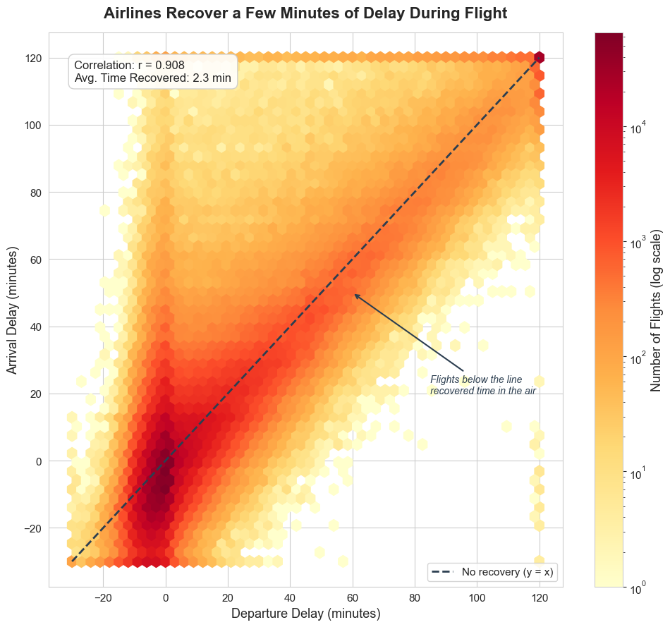

```python
# Polished Visualization 2: Hexbin density of dep delay vs arr delay
both_valid = df[df['DepDelay'].notna() & df['ArrDelay'].notna()]
corr = both_valid[['DepDelay', 'ArrDelay']].corr().iloc[0, 1]
recovery = (both_valid['DepDelay'] - both_valid['ArrDelay']).mean()

fig, ax = plt.subplots(figsize=(10, 9))
hb = ax.hexbin(both_valid['DepDelay'].clip(-30, 120),
               both_valid['ArrDelay'].clip(-30, 120),
               gridsize=50, cmap='YlOrRd', mincnt=1,
               bins='log')

# Reference line
ax.plot([-30, 120], [-30, 120], color='#2c3e50', linestyle='--',
        linewidth=2, label='No recovery (y = x)')

# Annotations
ax.text(0.05, 0.95,
        f'Correlation: r = {corr:.3f}\nAvg. Time Recovered: {recovery:.1f} min',
        transform=ax.transAxes, fontsize=12, verticalalignment='top',
        bbox=dict(boxstyle='round,pad=0.5', facecolor='white',
                  edgecolor='#cccccc', alpha=0.9))

# Arrow annotation pointing below the diagonal
ax.annotate('Flights below the line\nrecovered time in the air',
            xy=(60, 50), xytext=(85, 20),
            fontsize=10, fontstyle='italic', color='#2c3e50',
            arrowprops=dict(arrowstyle='->', color='#2c3e50', lw=1.5))

cb = fig.colorbar(hb, ax=ax, label='Number of Flights (log scale)')
ax.set_title('Airlines Recover a Few Minutes of Delay During Flight',
             fontsize=16, fontweight='bold', pad=15)
ax.set_xlabel('Departure Delay (minutes)', fontsize=13)
ax.set_ylabel('Arrival Delay (minutes)', fontsize=13)
ax.legend(loc='lower right', fontsize=11)

plt.tight_layout()
plt.show()
```

## Visualization 3: What Causes Delays?

Not all delays are created equal. The BTS categorizes delays into five causes: carrier-related, weather, National Airspace System (NAS), security, and late aircraft. Understanding which causes contribute the most total delay minutes reveals where the biggest improvement opportunities lie.

**Design choice:** A grouped bar chart was chosen to enable direct comparison of delay causes within each airline. Color-coding by cause type (red for late aircraft to draw attention to the dominant cause) makes the key pattern immediately visible. Airlines are ordered by total delay to create a natural reading flow from worst to best.

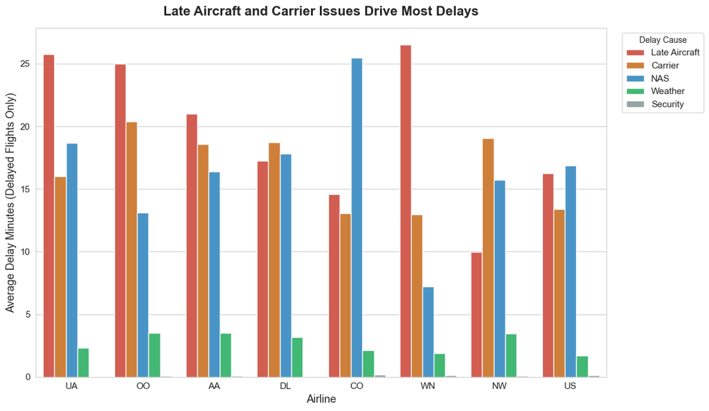

```python
# Polished Visualization 3: Delay cause breakdown by top airlines
delay_cols = ['CarrierDelay', 'WeatherDelay', 'NASDelay',
              'SecurityDelay', 'LateAircraftDelay']
cause_labels = ['Carrier', 'Weather', 'NAS', 'Security', 'Late Aircraft']

# Get top 8 airlines by flight volume
top8 = df['Reporting_Airline'].value_counts().head(8).index.tolist()
delayed = df[df[delay_cols].notna().all(axis=1) &
             df['Reporting_Airline'].isin(top8)].copy()

# Compute mean delay by cause for each airline
cause_by_airline = []
for col, label in zip(delay_cols, cause_labels):
    group = delayed.groupby('Reporting_Airline')[col].mean().reset_index()
    group.columns = ['Airline', 'AvgDelay']
    group['Cause'] = label
    cause_by_airline.append(group)
cause_df = pd.concat(cause_by_airline, ignore_index=True)

# Order airlines by total mean delay across all causes
airline_order = (cause_df.groupby('Airline')['AvgDelay'].sum()
                 .sort_values(ascending=False).index.tolist())

# Define color palette
cause_palette = {'Late Aircraft': '#e74c3c', 'Carrier': '#e67e22',
                 'NAS': '#3498db', 'Weather': '#2ecc71',
                 'Security': '#95a5a6'}

fig, ax = plt.subplots(figsize=(12, 7))
sns.barplot(data=cause_df, x='Airline', y='AvgDelay', hue='Cause',
            order=airline_order,
            hue_order=['Late Aircraft', 'Carrier', 'NAS', 'Weather', 'Security'],
            palette=cause_palette, edgecolor='white', ax=ax)

ax.set_title('Late Aircraft and Carrier Issues Drive Most Delays',
             fontsize=16, fontweight='bold', pad=15)
ax.set_xlabel('Airline', fontsize=13)
ax.set_ylabel('Average Delay Minutes (Delayed Flights Only)', fontsize=13)
ax.legend(title='Delay Cause', bbox_to_anchor=(1.02, 1), loc='upper left',
          frameon=True, edgecolor='#cccccc')

plt.tight_layout()
plt.show()
```

## Visualization 4: Seasonal Patterns in Delay Rates

Travel demand and weather conditions change dramatically by season. This chart shows how the percentage of delayed flights varies month by month for the five busiest airlines.

**Design choice:** A multi-line chart was chosen over a grouped bar chart because it emphasizes the seasonal trend shape and makes it easy to see that all carriers follow the same pattern. Shaded regions for summer and holiday periods provide immediate context. The `Set2` color palette ensures lines are distinguishable even for colorblind readers.

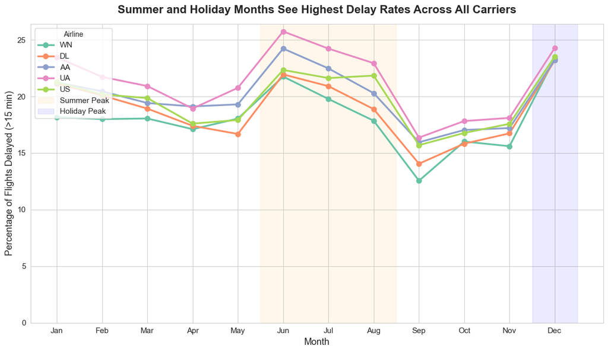

```python
# Polished Visualization 4: Delay rate by month for top 5 airlines
top5 = df['Reporting_Airline'].value_counts().head(5).index.tolist()
valid = df[df['ArrDel15'].notna() & df['Reporting_Airline'].isin(top5)]

monthly_rate = (valid.groupby(['MonthName', 'Reporting_Airline'])['ArrDel15']
                .mean().reset_index())
monthly_rate['DelayPct'] = monthly_rate['ArrDel15'] * 100

fig, ax = plt.subplots(figsize=(12, 7))
palette = sns.color_palette('Set2', n_colors=5)

for i, airline in enumerate(top5):
    subset = monthly_rate[monthly_rate['Reporting_Airline'] == airline]
    ax.plot(subset['MonthName'], subset['DelayPct'],
            marker='o', linewidth=2.5, markersize=7,
            label=airline, color=palette[i])

# Shade summer and holiday periods
ax.axvspan(4.5, 7.5, alpha=0.08, color='orange', label='Summer Peak')
ax.axvspan(10.5, 11.5, alpha=0.08, color='blue', label='Holiday Peak')

ax.set_title('Summer and Holiday Months See Highest Delay Rates Across All Carriers',
             fontsize=16, fontweight='bold', pad=15)
ax.set_xlabel('Month', fontsize=13)
ax.set_ylabel('Percentage of Flights Delayed (>15 min)', fontsize=13)
ax.legend(title='Airline', loc='upper left', frameon=True, edgecolor='#cccccc')
ax.set_ylim(bottom=0)

plt.tight_layout()
plt.show()
```

**Conclusion:** Flight delays in the U.S. are highly systematic. They follow predictable patterns by time of day, season, and cause. The single most actionable insight for travelers is to **book early morning departures** -- these flights haven't yet been affected by the cascading delays that build throughout the day. For airlines, the data suggests that improving aircraft turnaround times and schedule buffer management (to reduce late aircraft delays) would have the largest impact on overall on-time performance.